# ATELIER 1 : AGRICULTURE

Auteur·rice

FOFANA Kagnatie Zodihi Rahimat-Samira, KONE Mamadou, MONNEY Rodatine Flore, ZIDAGO Martinien Stéphane,

Date de publication

2025-05-27

> Exemple de traitement réalisé par les groupes d’auditeur à partir de l’enquête AfroMapR.

# 1. Préparation des données

## Choix des variables à analyser

On sélectionne dans le tableau une variable Y que l’on veut expliquer et une variables X qui peut servir à expliquer Y. On décide par exemple d’examiner les variables suivantes :

- **Y : alim** : sentiment d’insécurité alimentaire
- **X : statut** : statut matrimonial

## Recodage éventuel des étiquettes

On peut raccourcir ou modifier les étiquettes pour faciliter leur affichage ou fusionner des modalités trop peu nombreuses. Ici on a décidé de regrouper les personnes mariées et divorcées.

# 2. Analyse de la variable à expliquer Y

## Fréquence simple

| Modalité | Fréquence |
| --- | --- |
| non | 84 |
| oui | 27 |
| Sum | 111 |

## Pourcentage

| Modalité | % |
| --- | --- |
| non | 75.7 |
| oui | 24.3 |
| Sum | 100.0 |

## Diagramme en bâtons

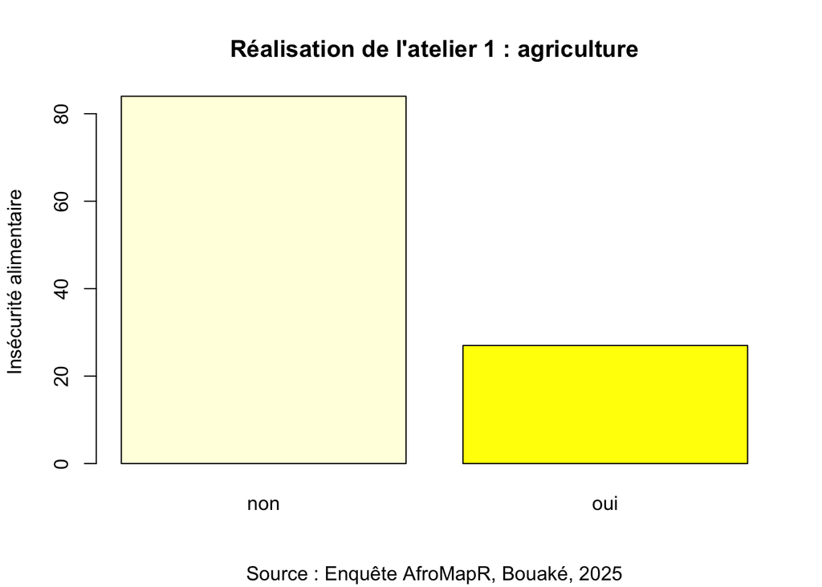

# 3. Analyse de la variable explicative X

## Fréquence simple

| Modalité | Fréquence |
| --- | --- |
| Celibataire | 21 |
| Couple | 90 |
| Sum | 111 |

## Pourcentage

| Modalité | % |
| --- | --- |
| Celibataire | 18.9 |
| Couple | 81.1 |
| Sum | 100.0 |

## Diagramme en bâtons

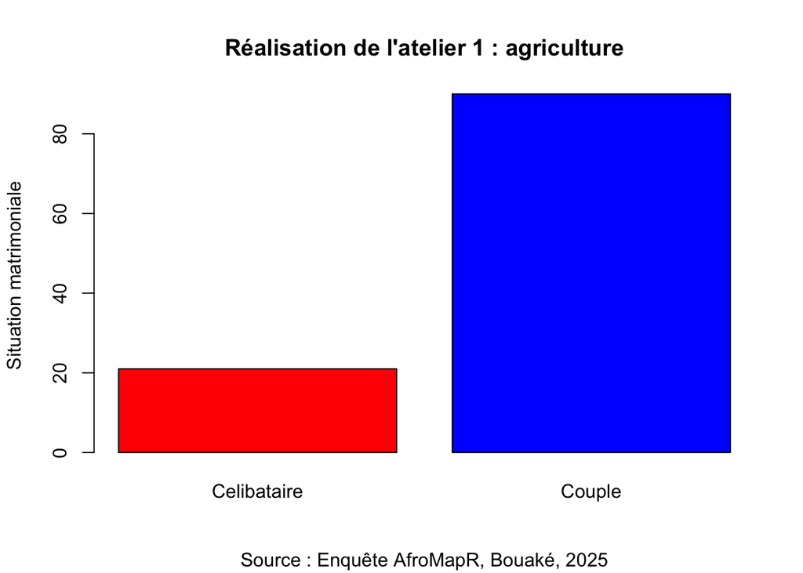

# 4. Relation entre X et Y

## Hypothèses

On veut tester l’existence d’une relation entre les deux variables précédentes.

- **H0** : Il n’y a pas de relation entre X et Y
- **H1** : Il y a une relation entre X et Y
- **Justification de l’hypothèse H1** : On suppose que les personnes mariées ont moins de risque d’insécrurité alimentaire que les personnes célibataires vivant seules.

## Tableau de contingence

|  | non | oui | Sum |
| --- | --- | --- | --- |
| Celibataire | 13 | 8 | 21 |
| Couple | 71 | 19 | 90 |
| Sum | 84 | 27 | 111 |

## Pourcentage en ligne

|  | non | oui | Sum |
| --- | --- | --- | --- |
| Celibataire | 61.9 | 38.1 | 100 |
| Couple | 78.9 | 21.1 | 100 |
| Sum | 75.7 | 24.3 | 100 |

On constate que les célibataires ont en effet un sentiment d’insécurité alimentaire plus important (38%) que les personnes vivant en couple (21%). Mais ces différences sont-elles significatives ?

## Graphique en mosaïque

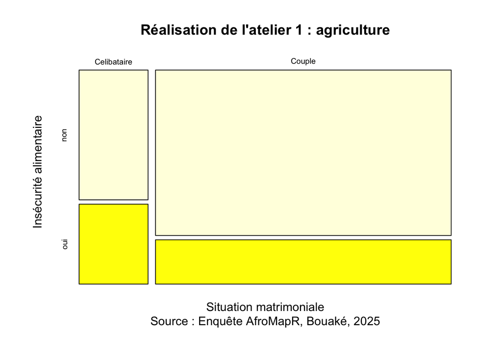

## Test du chi-2

On part de l’hypothèse nulle H0 : il n’y a pas de relation entre X et Y. Les variations en Y en fonction de X sont l’effet du hasard.

On effectue un test du chi-2 qui donne les résultats suivants :

```
    Pearson's Chi-squared test with Yates' continuity correction

data:  tabcont
X-squared = 1.8254, df = 1, p-value = 0.1767
```

## Conclusion

Il n’est pas possible de rejeter l’hypothèse H0 puisque la p-value indique que la relation entre les deux variable a 17.6% de chances d’être l’effet du hasard.

La relation existe peut-être mais notre échantillon est trop petit ou pas assez représentatif pour le démontrer.